# Math 504 HW11

Jeff Gould

4/1/2020

## 2

### a

$$S(x) = \sum_{j=1}^D\alpha_j h_j (x) = \alpha_1h_1(x) +\alpha_2h_2(x) +\dots +\alpha_Dh_D(x)$$
which create a linear function space $F$, We have previously shown that
$$\min_{f\in F} \sum_{i=1}^N(y_i - f(x^{(i)}))^2 = \min_{\alpha \in \mathbb{R}^k} ||y-B\alpha||^2$$
where $B$ is an $N \times K$ matrix of functions of $b_i(x)$, where entry $B_{kl} = b_l(x_k)$ in a linear function space $F$, and $\alpha$ is the coefficients. So with $S(x)$ being the $f(x)$, $h_j(x)$ is analogous to $b_j(x)$, and the $\alpha$’s fill the same roll. Then

$$\min_{S\in F}\sum_{i=1}^N (y_i - S(x_i))^2 = \min_{\alpha \in \mathbb{R}^k}||y - B \alpha||^2 \rightarrow \alpha = (B^TB)^{-1}B^Ty$$
where as mentioned $\alpha$ is the vector of $\alpha_j$’s, and each $B_{kl} = h_l(x_k)$

### b

$$S(x) = \bigg\{
\begin{array}{cc}
S_0(x) & \text{if } x < \xi_1 \\
S_1(x) & \text{if } x \in [\xi_1,\xi_2) \\
S_2(x) & \text{if } x \ge \xi_2,
\end{array} = \alpha_0 +\alpha_1 x + \alpha_2 x^2 + _3 x^3$$

### d

```r
bone_mass <- read_delim("BoneMassData.txt", delim = " ")

females <- bone_mass %>% filter(gender == "female")


y <- females$spnbmd
x <- females$age

h_5 <- function(x, zeta_1 = 15){ifelse((x - zeta_1) > 0, (x - zeta_1)^3, 0)}
h_6 <- function(x, zeta_2 = 20){ifelse((x - zeta_2) > 0, (x - zeta_2)^3, 0)}

B <- matrix(
  c(rep(1, length(x)),
  x,
  x^2,
  x^3,
  h_5(x),
  h_6(x)),
  ncol = 6
)

alpha <- solve(t(B) %*% B) %*% t(B) %*% y
```

So $S(x) =$-4.2488263 + 0.9762416$x$ + -0.0716499$x^2$ + 0.0017069$x^3$ + -0.0021305$[x-15]_+^3$ + 7.280495710^{-4}$[x-20]_+^3$

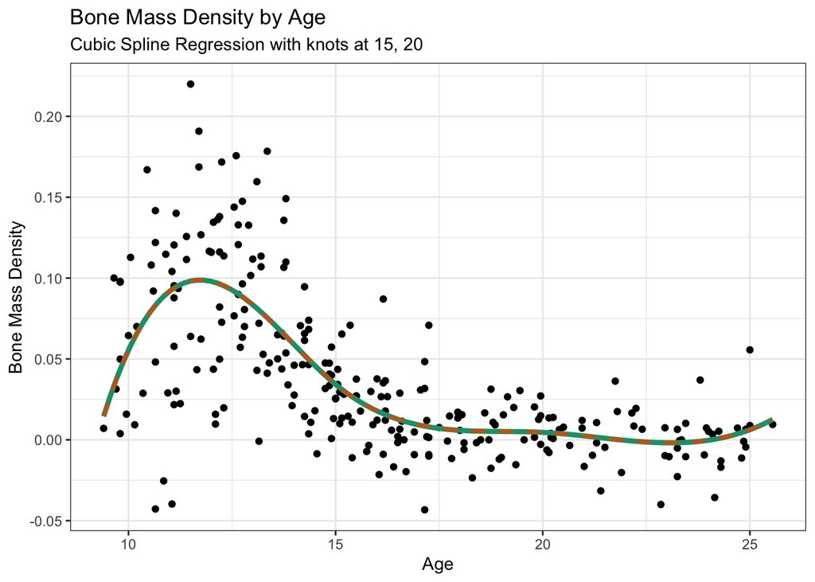

```r
S_x <- function(x, zeta_1 = 15, zeta_2 = 20, A = alpha){
  H <- matrix(
    c(rep(1, length(x)),
    x,
    x^2,
    x^3,
    h_5(x),
    h_6(x)),
    ncol = 6
  )
  Sx <- apply(H,1,function(x){sum(A*x)})
  return(Sx)
}

ggplot(data = females, aes(x = age, y = spnbmd)) +
  geom_point() +
  theme_bw() +
  stat_function(fun = S_x, color = "#1B9E77", size = 1.5) +
  geom_smooth(method = "lm", formula = y ~ bs(x, knots=c(15,20)),
              alpha = 0, color = "#D95F02", linetype = 2, size = 1) +
  labs(x = "Age", y = "Bone Mass Density",
       title = "Bone Mass Density by Age",
       subtitle = "Cubic Spline Regression with knots at 15, 20")
```

Here the solid teal line is our $S(x)$ plotted over the data, and the dashed orange line is the spline regression formed using the `bs` function to compute the spline with knots at 15 and 20. As you can see, the regressions match up perfectly.

## 3

$f(x) = e^x \rightarrow f'(x) = e^x \rightarrow f'(0)=1$

```r
options(digits = 16)
i <- seq(-20,0,1)
h <- 10^i

finite_difference_1 <- function(x,h){
  fx <- (exp(x + h) - exp(x)) / h

  return(fx)
}

finite_difference_2 <- function(x,h){
  fx <- (exp(x + h) - exp(x - h)) / (2 * h)

  return(fx)
}

differences_1 <- sapply(h, finite_difference_1, x = 0)
differences_2 <- sapply(h, finite_difference_2, x = 0)

results <- data.frame(
  h = format(10^i, scientific = T, digits = 2),
  fin_diff_1 = differences_1,
  fin_diff_2 = differences_2
)

print(xtable::xtable(results, digits = 16), comment = F)
```

[output not shown]

## 4

In general, the cdf $F(x)$ of a distribution is $P(X\leq x) \rightarrow P(-\infty < X \leq x)$. However here we have defined $F(X)$ with a lower bound of 0. Since we know the standard normal distribution is centered at 0, with $P(X\leq 0) = 0.5$ and $P(X>0) = 0.5$, then
$$F(x) = \int_{0}^x dz \frac{1}{\sqrt{2\pi}} \text{e}^{-z^2/2} \rightarrow F(\infty) = 0.5$$
Using `R`’s built in integrate function, we see that an upper limit of 7.5 gives a value of 0.4999999999999883, accurate to 12 decimal places, so we set the upper limit for our subdivisions at 7.5. Increasing the upperbound beyond this will give us minimal added area and increase our error. However, we make this bound adjustable to the function’s user.

```r
norm_cdf <- function(z){1 / (sqrt(2 * pi)) * exp(-z^2 / 2)}
integrate(norm_cdf, 0, 7.5, subdivisions = 100)
```

0.4999999999999883 with absolute error < 3.2e-07

```r
Fapprox <- function(n, method = "reimann", upperlimit = 7.5){
  `%notin%` = Negate(`%in%`)
  if(method %notin% c("reimann", "trapezoid", "useR")){
    return("Please enter a valid integration method")
  }

  h <- upperlimit / n

  rectangle <- function(z){
    height <- 1 / sqrt(2 * pi) * exp(-(z^2) / 2)
    width <- h
    area <- height * width
    return(area)
  }

  trapezoid <- function(z){
    height_1 <- 1 / sqrt(2 * pi) * exp(-(z^2) / 2)
    height_2 <- 1 / sqrt(2 * pi) * exp(-((z + h)^2) / 2)
    area <- (height_1 + height_2) / 2 * h

  }

  if(method == "reimann"){
    cuts <- seq(0, upperlimit, h)
    norm_cdf <- sum(sapply(cuts[-n], rectangle))
  }else if(method == "trapezoid"){
    cuts <- seq(0, upperlimit, h)
    norm_cdf <- sum(sapply(cuts[-n], trapezoid))
  }else{
    norm_cdf_func <- function(z){1 / (sqrt(2 * pi)) * exp(-z^2 / 2)}
    norm_cdf <- integrate(norm_cdf_func, 0,
                          upperlimit,
                          subdivisions = n)$value
  }
  return(norm_cdf)

}

n_s <- c(10,100,1000,10000)
evaluations <- data.frame(
  n = format(n_s, digits = 0),
  Riemann = sapply(n_s, Fapprox),
  Trapezoid = sapply(n_s, Fapprox, method = "trapezoid"),
  useR = sapply(n_s, Fapprox, method = "useR")
)

print(xtable::xtable(evaluations, digits = 16), comment = F)
```

[output not shown]